# Assignment 19 - Clusters

## Portfolio assignment 19

30 min: Create a cluster model on the penguins dataset.

- Use the pairplot() function on the penguins dataset. Do you visually notice any clusters? How many clusters do you think there are?
- Use the KMeans algorithm to create a cluster model. Apply this model to the dataset to create an extra column 'cluster' just like we did for the iris dataset above.  
  **Note**: Some machine learning algorithms can not handle missing values. You will either need to
  - replace missing values (with the mean or most popular value). For replacing missing values you can use .fillna(\<value>) https://pandas.pydata.org/docs/reference/api/pandas.Series.fillna.html
  - remove rows with missing data. You can remove rows with missing data with .dropna() https://pandas.pydata.org/pandas-docs/stable/reference/api/pandas.DataFrame.dropna.html
- Calculate the Silhouette Coefficient for your clustering. Play around with the features and n_clusters to search for better results. Keep the cluster model with the highest Silhouette Coefficient.
- Use the pairplot(hue='cluster') function to observe how the model has clustered the data.
- We know the species of each penguin. Use a contingency table to reveal the relation between the cluster results and the species. Is there an exact match? Are there species which ended up in the same cluster? If so, what does it mean that they ended up in the same cluster?

```python
import pandas as pd
import seaborn as sns
from sklearn.cluster import KMeans
```

```python
penguin = sns.load_dataset("penguins")
penguin.head()
```

|  | species | island | bill_length_mm | bill_depth_mm | flipper_length_mm | body_mass_g | sex |
| --- | --- | --- | --- | --- | --- | --- | --- |
| 0 | Adelie | Torgersen | 39.1 | 18.7 | 181.0 | 3750.0 | Male |
| 1 | Adelie | Torgersen | 39.5 | 17.4 | 186.0 | 3800.0 | Female |
| 2 | Adelie | Torgersen | 40.3 | 18.0 | 195.0 | 3250.0 | Female |
| 3 | Adelie | Torgersen | NaN | NaN | NaN | NaN | NaN |
| 4 | Adelie | Torgersen | 36.7 | 19.3 | 193.0 | 3450.0 | Female |

## Pairplot

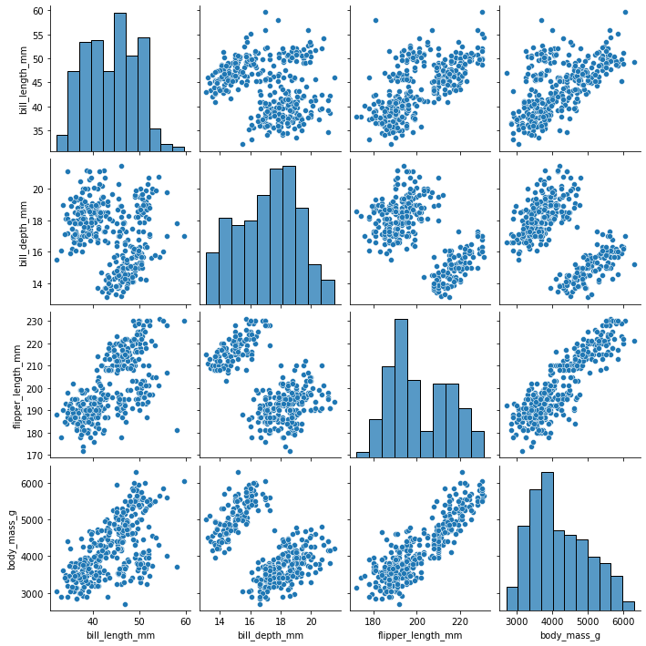

```python
sns.pairplot(penguin)
```

#### Do you visually notice any clusters? How many clusters do you think there are?

##### Ja. Ik denk dat er twee clusters zijn.

## Filling & Cluster Model

```python
value = {'bill_length_mm': penguin['bill_length_mm'].mean(), 'bill_depth_mm': penguin['bill_depth_mm'].mean(),
         'flipper_length_mm': penguin['flipper_length_mm'].mean(), 'body_mass_g': penguin['body_mass_g'].mean(),
         'sex': 'Unkown'}
penguin = penguin.fillna(value = value)
```

```python
features = ['body_mass_g','flipper_length_mm','bill_depth_mm', 'bill_length_mm']
km = KMeans(n_clusters=2, random_state=42).fit(penguin[features])
```

```python
penguin['cluster'] = km.predict(penguin[features])
```

```python
penguin.head()
```

|  | species | island | bill_length_mm | bill_depth_mm | flipper_length_mm | body_mass_g | sex | cluster |
| --- | --- | --- | --- | --- | --- | --- | --- | --- |
| 0 | Adelie | Torgersen | 39.10000 | 18.70000 | 181.000000 | 3750.000000 | Male | 0 |
| 1 | Adelie | Torgersen | 39.50000 | 17.40000 | 186.000000 | 3800.000000 | Female | 0 |
| 2 | Adelie | Torgersen | 40.30000 | 18.00000 | 195.000000 | 3250.000000 | Female | 0 |
| 3 | Adelie | Torgersen | 43.92193 | 17.15117 | 200.915205 | 4201.754386 | Unkown | 0 |
| 4 | Adelie | Torgersen | 36.70000 | 19.30000 | 193.000000 | 3450.000000 | Female | 0 |

```python
penguin.cluster.value_counts()
```

```
0    211
1    133
Name: cluster, dtype: int64
```

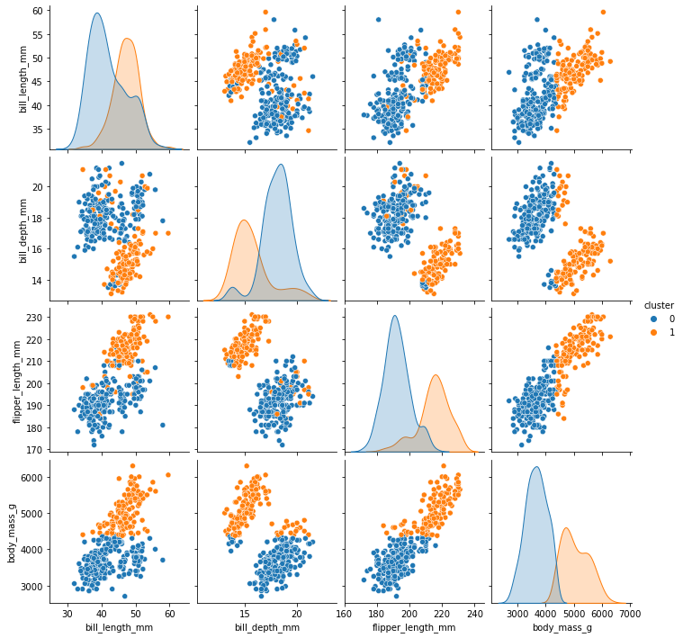

```python
sns.pairplot(penguin, hue="cluster")
```

## Silhouette Coefficient

```python
from sklearn import metrics
from sklearn.metrics import pairwise_distances
```

```python
# You can change the features and n_clusters in the k-means above and check the impact on the Silhouette Coefficient
metrics.silhouette_score(penguin[features], km.labels_, metric='euclidean')
```

```
0.6270788983241281
```

##### Clusters = 2 geeft 0.627, Clusters = 3 geeft 0.579, Clusters = 4 geeft 0,0554

## Contingency Table

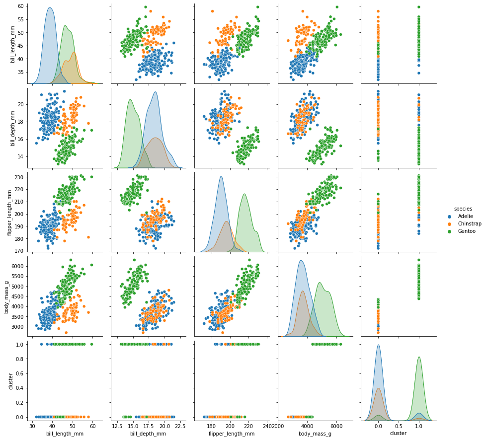

```python
sns.pairplot(penguin, hue="species")
```

```python
contingency_table = penguin.groupby(['species','cluster']).size().unstack('cluster', fill_value=0)
contingency_table
```

| cluster species | 0 | 1 |
| --- | --- | --- |
| Adelie | 138 | 14 |
| Chinstrap | 63 | 5 |
| Gentoo | 10 | 114 |

#### We know the species of each penguin. Use a contingency table to reveal the relation between the cluster results and the species. Is there an exact match? Are there species which ended up in the same cluster? If so, what does it mean that they ended up in the same cluster?

##### Er is geen exacte match. Alle species zijn in iedere kluster te vinden. Dit houdt in dat je de penguins niet goed op basis van de flipper_length, body_mass, bill_depth en bill_depth in te delen zijn in groepen.